# Data605-HW15

Santosh Manjrekar

December 9, 2018

## 1. Find the equation of the regression line for the given points.

Round any final values to the nearest hundredth, if necessary. ( 5.6, 8.8 ), ( 6.3, 12.4 ), ( 7, 14.8 ), ( 7.7, 18.2 ), ( 8.4, 20.8 )

$$\beta_1 = \frac{\sum_{i=1}^n (x_i-\bar{X})(y_i-\bar{Y})}{\sum_{i=1}^n (x_i-\bar{X})^2} \\
\beta_1 = \frac{Cov(x,y)}{Var(x)}\\
\beta_0 = \bar{Y} - m\bar{X} \\$$

We can use R to show this manually, and then use the lm() function to check our work.

```r
x = c(5.6, 6.3, 7, 7.7, 8.4)
y = c(8.8, 12.4, 14.8, 18.2, 20.8)
x_bar = mean(x)
x_bar
```

```
## [1] 7
```

```r
y_bar = mean(y)
y_bar
```

```
## [1] 15
```

```r
x_x_bar = x-x_bar
sq_x_xbar = (x_x_bar)^2
sq_x_xbar
```

```
## [1] 1.96 0.49 0.00 0.49 1.96
```

```r
var_x = sum(sq_x_xbar)/(length(x)-1)
var_x
```

```
## [1] 1.225
```

```r
var(x) #check my work
```

```
## [1] 1.225
```

```r
y_y_bar = y-y_bar
y_y_bar
```

```
## [1] -6.2 -2.6 -0.2  3.2  5.8
```

```r
prod_x_y = x_x_bar*y_y_bar
prod_x_y
```

```
## [1] 8.68 1.82 0.00 2.24 8.12
```

```r
cov_xy = sum(prod_x_y)/(length(x)-1)
cov_xy
```

```
## [1] 5.215
```

```r
cov(x,y) #check my work
```

```
## [1] 5.215
```

```r
B_1 = cov_xy/var_x
B_1
```

```
## [1] 4.257143
```

```r
B_0 = y_bar - B_1*x_bar
B_0
```

```
## [1] -14.8
```

Rounded to the nearest hundredth place:

$$y = -14.8 + 4.26*x$$

```r
fit <- lm(y~x)
summary(fit)
```

```
##
## Call:
## lm(formula = y ~ x)
##
## Residuals:
##     1     2     3     4     5
## -0.24  0.38 -0.20  0.22 -0.16
##
## Coefficients:
##             Estimate Std. Error t value Pr(>|t|)
## (Intercept) -14.8000     1.0365  -14.28 0.000744 ***
## x             4.2571     0.1466   29.04 8.97e-05 ***
## ---
## Signif. codes:  0 '***' 0.001 '**' 0.01 '*' 0.05 '.' 0.1 ' ' 1
##
## Residual standard error: 0.3246 on 3 degrees of freedom
## Multiple R-squared:  0.9965, Adjusted R-squared:  0.9953
## F-statistic: 843.1 on 1 and 3 DF,  p-value: 8.971e-05
```

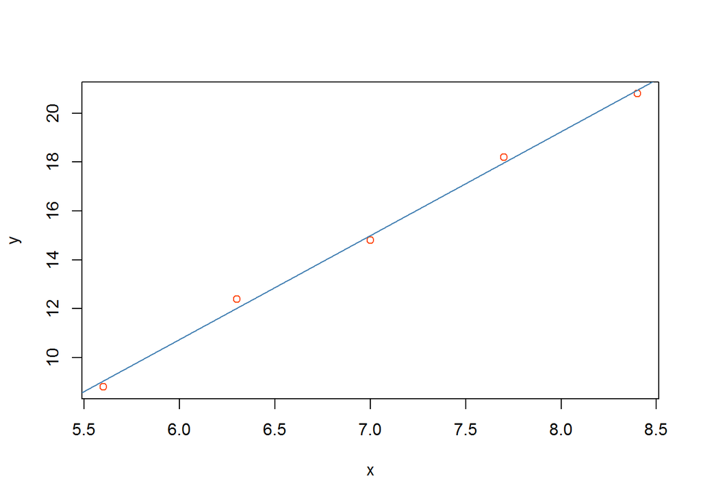

```r
plot(x,y, col = 'orangered')
abline(fit, col = 'steelblue')
```

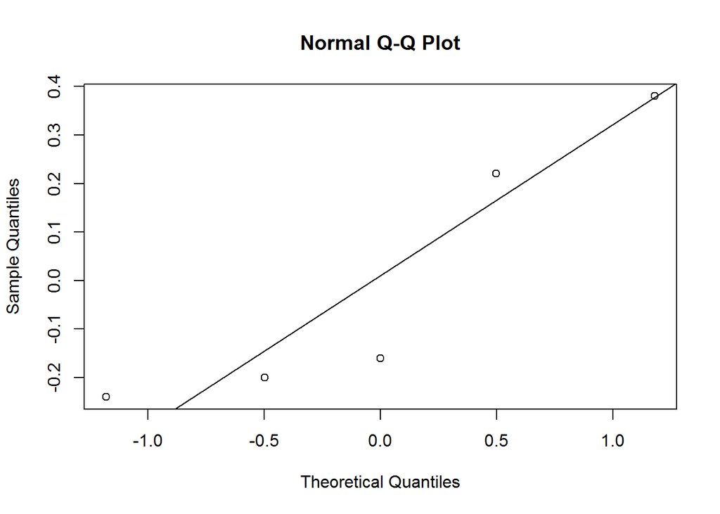

```r
qqnorm(resid(fit))
qqline(resid(fit))
```

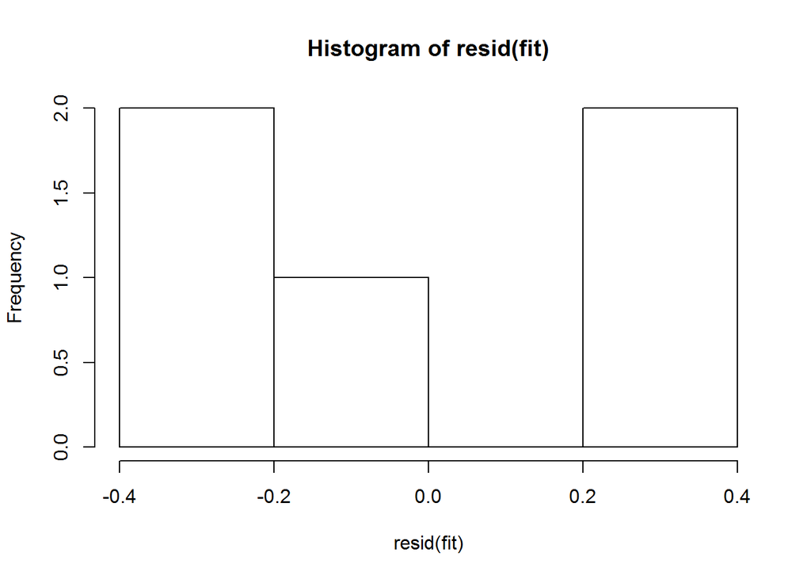

```r
hist(resid(fit))
```

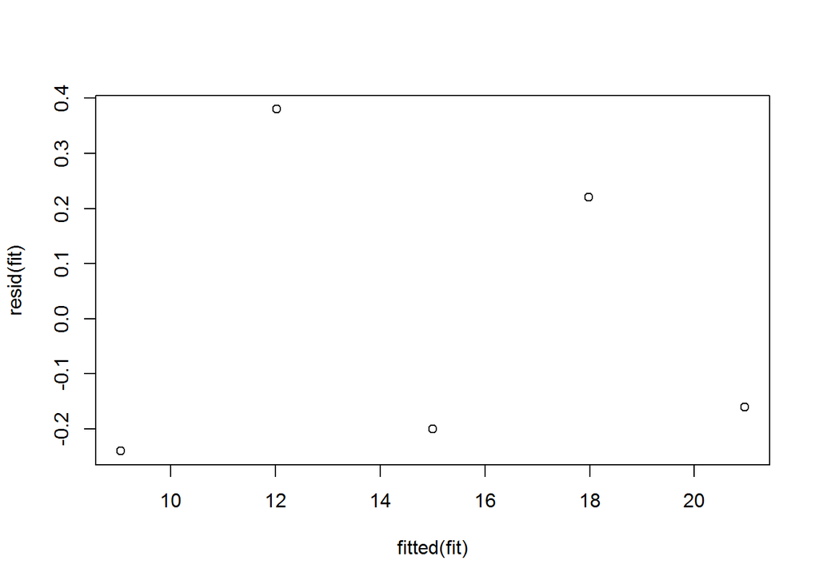

```r
plot(fitted(fit),resid(fit))
```

```r
shapiro.test(resid(fit))
```

```
##
##  Shapiro-Wilk normality test
##
## data:  resid(fit)
## W = 0.83427, p-value = 0.1497
```

It’s hard to visualize the normality of only 5 data points so the Shaprio-Wilks test was used; since the p-value of 0.1497 is $> 0.05$, we must accept the null hypothesis that the residuals come from a Normal Distribution.

According to lm():

$$y = -14.8 + 4.26*x$$

rounded to the nearest 100th.

## 2. Find all local maxima, local minima, and saddle points for the function given below.

Write your answer(s) in the form (x, y, z). Separate multiple points with a comma.

$$f(x,y) = 24x-6xy^2-8y^3 \\
f_x = 24 - 6y^2 \\
f_y = -12xy - 24y^2 \\
24-6y^2 = 0 \space\&\space -12xy-24y^2 = 0 \\
y = \sqrt{\frac{24}{6}} = \pm2 \\
x = -2y = \mp4 \\$$

```r
 crit_finder <- function(x,y){
   z = 24*x-6*x*y^2-8*y^3
   return(c(x,y,z))
 }
crit_finder(-4,2)
```

```
## [1]  -4   2 -64
```

```r
crit_finder(4,-2)
```

```
## [1]  4 -2 64
```

```r
min_max <- function(x,y){
  D = (24 - 6*y^2)*(-12*x*y - 24*y^2) - 144*y^2
  if(D>0){
    return("maximum or minimum")
  }
  if(D<0){
    return("Saddle point")
  }
  else{
    return("Inconclusive")
  }
}
min_max(-4,2)
```

```
## [1] "Saddle point"
```

```r
min_max(4,-2)
```

```
## [1] "Saddle point"
```

## 3. A grocery store sells two brands of a product, the “house” brand and a “name” brand.

The manager estimates that if she  
sells the “house” brand for x dollars and the “name” brand for y dollars, she will be able to sell $81-21x+17y$ units of the “house” brand and $40+11x-23y$ units of the “name” brand.

Step 1. Find the revenue function R(x, y).

Revenue is the total amount of money brought in before overhead costs are removed. This will be number of units sold time price per unit.

$R(x,y) = x(81-21x+17y) + y(40+11x-23y)$

Step 2.What is the revenue if she sells the “house” brand for $2.30 and the “name” brand for $4.10?

$$R(x,y) = 2.3*(81-21*2.3+17*4.1)+4.1*(40+11*2.3-23*4.1)\\
R(x,y) = 116.62\space USD$$

## 4. A company has a plant in Los Angeles and a plant in Denver.

The firm is committed to produce a total of 96 units of a product each week. The total weekly cost is given by $C(x,y) = \frac{1}{6}x^2 + \frac{1}{6}y^2 +7x +25y +700$, where x is the number of units produced in Los Angeles and y is the number of units produced in Denver. How many units should be produced in each plant to minimize the total weekly cost?

We need to find the critical points of C(x,y) and we need to make sure they make sense (i.e, both x and y are positive numbers) and that those critical numbers are minima. Since we have a constraint on x and y, we can use this to reduce the cost function to a single variable.

$$x+y=96 \\
C(x,y) = \frac{1}{6}x^2 + \frac{1}{6}y^2 +7x +25y +700 \\
C(x) = \frac{1}{6}x^2 + \frac{1}{6}(96-x)^2 +7x +25(96-x) +700\\
C(x) = \frac{1}{6}x^2 + 1536-32x + \frac{1}{6}x^2 +7x +2400-25x +700 \\
C(x) = \frac{1}{3}x^2 -50x +4636 \\
\frac{dC}{dx} = \frac{2}{3}x -50 =0 \\
x = 75 \\
\frac{d^2C}{dx^2} = \frac{2}{3}$$

Since the Second Derivative is $>0$, $x=75$ is a relative minima.

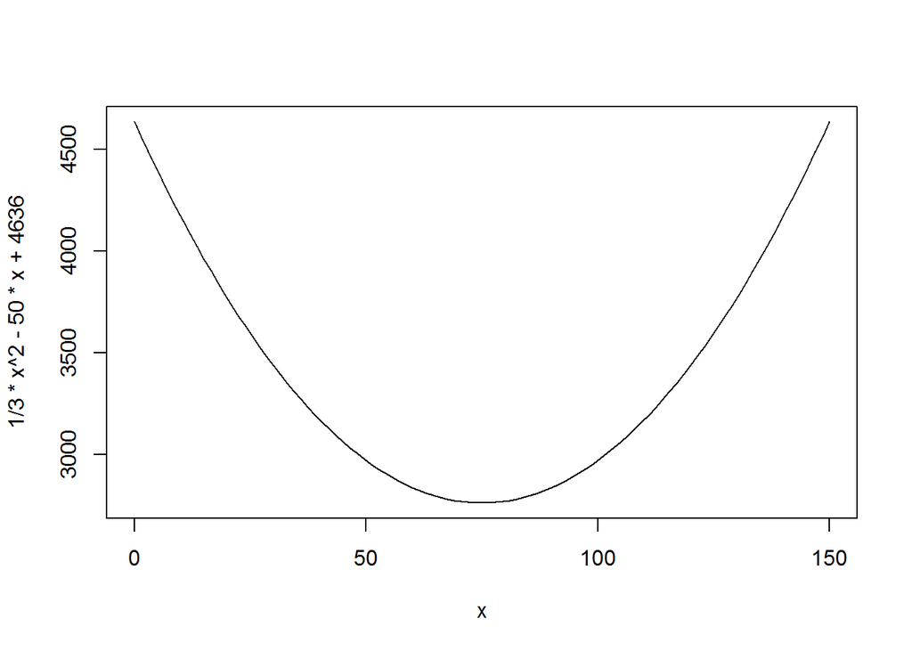

```r
curve(1/3*x^2-50*x+4636, from = 0, to = 150)
```

From the graph of the single dimension curve, we can see the critical point is an absolute minimum at $x=75$ as expected. This means we want to make 75 units in L.A. and 21 in Denver.

## 5. Evaluate the double integral on the given region.

$$A = \int_2^4\int_2^4 e^{(8x + 3y)} dA \\
A = \int_2^4\int_2^4 e^{8x} e^{3y} dxdy \\
A = \int_2^4 e^{8x}dx * \int_2^4 e^{3y}dy \\
A = \frac{1}{8} e^{8x}\Big|_2^4 * \frac{1}{3} e^{3y}\Big|_2^4 \\
A = \frac{1}{24}e^{8x}\Big|_2^4 * e^{3y}\Big|_2^4 \\
A = \frac{1}{24} (e^{32} - e^{16} )( e^{12} - e^{6})\\
A = 534,156,100,000,000,000$$

```r
1/24*((exp(32)+exp(16))*(exp(12) - exp(6)))
```

```
## [1] 5.341561e+17
```